# Schools in Ząbki 2008-2022

Katarzyna Piechocka

2023-12-28

## The problem - Primary Schools in Ząbki

The question is - do we need additional Primary Schools in Ząbki? If so - will building one school will be enough, or should we already plan next investments in coming years.

I know the problem from my own experience, that as many growing towns in suburb of Warsaw (and Warsaw as well), Ząbki urgently need more primary schools. Already existing one are already working on two or three shifts.

But lets focus on the data we have available: * number of students in Primary Schools in Ząbki (uczniowie) * number of classes in Primary Schools in Ząbki (oddziały) * number of Primary Schools in Ząbki (szkoły) * number of children up to 14 years old (in Poland, Primary Schools are for children 7-14 years old )

All data are shown for years 2008-2022

How will we answer the question: * Analysis of growing number of students in Ząbki primary schools (summarizing with grammar scholls which were closed due to reform of education system in Poland) * Analysis of number of classes (oddziały) and schools * Analysys of number of children population in Ząbki

## Data sources

This analysis was based on official open source data from GUS (Statistics Poland https://api.stat.gov.pl/Home/BdlApi?lang=en). Data collected using API BDL.

## Installing additional packages

To be able to retrieve necessary data from GUS I needed additional tools in R - I found and installed R_Package_to_API_BDL created by Polish statistician.

Full documentation available in GitGub: https://github.com/statisticspoland/R_Package_to_API_BDL

For analysis purposes popular R Packages and libraries will be installed: tidyverse, ggplot2.

```r
# Installing the packages
#install.packages("C:\Users\katar\Downloads\bdl_1.0.5.zip", repos = NULL, type = "source")
#install.packages("patchwork")

# Loading libraries
library(bdl)
library(tidyverse)
library(ggplot2)
library(patchwork)
```

## Checking structure od GUS data, sellecting correct codes for location and variables.

Looking for location code of Ząbki and for variables concerning schools, and children population

```r
# Searching for location code of Ząbki
search_units('ząbki')
```

```
## # A tibble: 1 × 6
##   id           name  parentId     level kind  unitHasChanged
##   <chr>        <chr> <chr>        <int> <chr> <lgl>
## 1 071412934031 Ząbki 071412934000     6 1     FALSE
```

```r
search_unit_localities('ząbki')
```

```
## # A tibble: 7 × 6
##   id                   name                parentId   level kind  unitHasChanged
##   <chr>                <chr>               <chr>      <int> <chr> <lgl>
## 1 023216410015-0177649 Jarząbki            023216410…     7 5     FALSE
## 2 042815611012-0475855 Janowiec-Jastrząbki 042815611…     7 2     FALSE
## 3 051011506052-0727305 Ząbki               051011506…     7 2     TRUE
## 4 051011521032-0727305 Ząbki               051011521…     7 2     TRUE
## 5 052615301022-0238300 Jarząbki            052615301…     7 2     FALSE
## 6 062013803072-0038936 Niemyje-Ząbki       062013803…     7 2     FALSE
## 7 071412934031-0921958 Ząbki               071412934…     7 1     FALSE
```

```r
# Searching for variable (codes) concerning schools in Zabki (regular Primary Schools)
szkoly <- data.frame(search_variables('szkoły'))
head(szkoly)
```

```
##    id subjectId                                                       n1
## 1 838     P1781 szkoły podstawowe dla dzieci i młodzieży bez specjalnych
## 2 839     P1781 szkoły podstawowe dla dzieci i młodzieży bez specjalnych
## 3 840     P1781 szkoły podstawowe dla dzieci i młodzieży bez specjalnych
## 4 841     P1781 szkoły podstawowe dla dzieci i młodzieży bez specjalnych
## 5 842     P1781 szkoły podstawowe dla dzieci i młodzieży bez specjalnych
## 6 843     P1781 szkoły podstawowe dla dzieci i młodzieży bez specjalnych
##                      n2
## 1                ogółem
## 2                ogółem
## 3                ogółem
## 4                ogółem
## 5 pomieszczenia szkolne
## 6 pomieszczenia szkolne
##                                                               n3 level
## 1                                                         ogółem     7
## 2                            prowadzone przez organy samorządowe     6
## 3 prowadzone przez jednostki administracji rządowej (centralnej)     7
## 4                         prowadzone przez organizacje społeczne     6
## 5                                                         ogółem     7
## 6                            prowadzone przez organy samorządowe     6
##   measureUnitId measureUnitName
## 1            35             ob.
## 2            35             ob.
## 3            35             ob.
## 4            35             ob.
## 5             1               -
## 6             1               -
```

```r
# Searching for variable - population data concerning children under 14 years old
wiek_14_lat_i_mniej <- search_variables('14 lat i mniej')
head(wiek_14_lat_i_mniej)
```

```
## # A tibble: 3 × 7
##      id subjectId n1                   n2    level measureUnitId measureUnitName
##   <int> <chr>     <chr>                <chr> <int>         <int> <chr>
## 1 72283 P2577     w wieku przedproduk… kobi…     6            26 osoba
## 2 72287 P2577     w wieku przedproduk… mężc…     6            26 osoba
## 3 72291 P2577     w wieku przedproduk… ogół…     6            26 osoba
```

Variable and Location Id we will be working with: * unit id for Ząbki - **071412934031** * localities id for Ząbki - **071412934031-0921958** * number of students - sum of two variables * students of primary schools - **862** * students of grammar schools - **2394** * number of schools - sum of two variables * number of primary schools - **838** * number of grammar schools - **2370** * number of classes (oddziały) - sum of two variables * number of classes in primary schools - **854** * number of classes in grammar schools - **2412** * population of children under 14 years old - **72291**

## Collecting data

All data were collected directly from GUS BDL API. Data collection step by step - a variable at time.

Later on single data frame with values of all variables will be created.

```r
# Students of primary schools
uczniowie <- data.frame(get_data_by_unit_locality(unitId = "071412934031-0921958", varId = 862))
head(uczniowie)
```

```
##    id year  val measureUnitId attrId attributeDescription
## 1 862 2008 1887            26      1
## 2 862 2009 1933            26      1
## 3 862 2010 2061            26      1
## 4 862 2011 2292            26      1
## 5 862 2012 2351            26      1
## 6 862 2013 2538            26      1
##               lastUpdate
## 1 2023-11-08T16:26:50.87
## 2 2023-11-08T16:26:50.87
## 3 2023-11-08T16:26:50.87
## 4 2023-11-08T16:26:50.87
## 5 2023-11-08T16:26:50.87
## 6 2023-11-08T16:26:50.87
```

```r
# Students of grammar schools
uczniowie_gim <- data.frame(get_data_by_unit_locality(unitId = "071412934031-0921958", varId = 2394))
head(uczniowie_gim)
```

```
##     id year  val measureUnitId attrId attributeDescription
## 1 2394 2008 1002            26      1
## 2 2394 2009 1041            26      1
## 3 2394 2010 1038            26      1
## 4 2394 2011 1031            26      1
## 5 2394 2012 1012            26      1
## 6 2394 2013 1066            26      1
##                lastUpdate
## 1 2021-01-22T08:18:41.827
## 2 2021-01-22T08:18:41.827
## 3 2021-01-22T08:18:41.827
## 4 2021-01-22T08:18:41.827
## 5 2021-01-22T08:18:41.827
## 6 2021-01-22T08:18:41.827
```

```r
# Number of primary schools
szkoly <- data.frame(get_data_by_unit_locality(unitId = "071412934031-0921958", varId = 838))
head(szkoly)
```

```
##    id year val measureUnitId attrId attributeDescription             lastUpdate
## 1 838 2008   4            35      1                      2023-11-08T16:26:50.87
## 2 838 2009   4            35      1                      2023-11-08T16:26:50.87
## 3 838 2010   5            35      1                      2023-11-08T16:26:50.87
## 4 838 2011   6            35      1                      2023-11-08T16:26:50.87
## 5 838 2012   5            35      1                      2023-11-08T16:26:50.87
## 6 838 2013   5            35      1                      2023-11-08T16:26:50.87
```

```r
# Number of grammar schools
szkoly_gim <- data.frame(get_data_by_unit_locality(unitId = "071412934031-0921958", varId = 2370))
head(szkoly_gim)
```

```
##     id year val measureUnitId attrId attributeDescription
## 1 2370 2008   3            35      1
## 2 2370 2009   3            35      1
## 3 2370 2010   3            35      1
## 4 2370 2011   3            35      1
## 5 2370 2012   3            35      1
## 6 2370 2013   3            35      1
##                lastUpdate
## 1 2021-01-22T08:18:41.827
## 2 2021-01-22T08:18:41.827
## 3 2021-01-22T08:18:41.827
## 4 2021-01-22T08:18:41.827
## 5 2021-01-22T08:18:41.827
## 6 2021-01-22T08:18:41.827
```

```r
# Number of classes in primary schools
oddziały <- data.frame(get_data_by_unit_locality(unitId = "071412934031-0921958", varId = 854))
head(oddziały)
```

```
##    id year val measureUnitId attrId attributeDescription             lastUpdate
## 1 854 2008  81             1      1                      2023-11-08T16:26:50.87
## 2 854 2009  82             1      1                      2023-11-08T16:26:50.87
## 3 854 2010  89             1      1                      2023-11-08T16:26:50.87
## 4 854 2011  99             1      1                      2023-11-08T16:26:50.87
## 5 854 2012  99             1      1                      2023-11-08T16:26:50.87
## 6 854 2013 107             1      1                      2023-11-08T16:26:50.87
```

```r
# Number of classes in grammar schools
szkoly_gim_oddz <- data.frame(get_data_by_unit_locality(unitId = "071412934031-0921958", varId = 2412))
head(szkoly_gim_oddz)
```

```
##     id year val measureUnitId attrId attributeDescription
## 1 2412 2008  40             1      1
## 2 2412 2009  40             1      1
## 3 2412 2010  40             1      1
## 4 2412 2011  40             1      1
## 5 2412 2012  38             1      1
## 6 2412 2013  39             1      1
##                lastUpdate
## 1 2021-01-22T08:18:41.827
## 2 2021-01-22T08:18:41.827
## 3 2021-01-22T08:18:41.827
## 4 2021-01-22T08:18:41.827
## 5 2021-01-22T08:18:41.827
## 6 2021-01-22T08:18:41.827
```

```r
# Population of children under up to 14 years old in Ząbki
lud_do14_kraj1 <- get_data_by_variable(varId = 72291)
head(lud_do14_kraj1)
```

```
## # A tibble: 6 × 8
##   id    name  year     val measureUnitId measureName attrId attributeDescription
##   <chr> <chr> <chr>  <int> <chr>         <chr>        <int> <chr>
## 1 0000… POLS… 1995  8.68e6 26            osoba            1 ""
## 2 0000… POLS… 1996  8.45e6 26            osoba            1 ""
## 3 0000… POLS… 1997  8.17e6 26            osoba            1 ""
## 4 0000… POLS… 1998  7.86e6 26            osoba            1 ""
## 5 0000… POLS… 1999  7.58e6 26            osoba            1 ""
## 6 0000… POLS… 2000  7.29e6 26            osoba            1 ""
```

Other method of data collection, all variables in a single data frame. I have decided not to use it in this analysis

```r
dane <- data.frame(get_data_by_unit_locality(unitId = "071412934031-0921958", varId = c(862,2394,838,2370,854,2412)))
head(dane)
```

```
##    id year val measureUnitId attrId attributeDescription             lastUpdate
## 1 838 2008   4            35      1                      2023-11-08T16:26:50.87
## 2 838 2009   4            35      1                      2023-11-08T16:26:50.87
## 3 838 2010   5            35      1                      2023-11-08T16:26:50.87
## 4 838 2011   6            35      1                      2023-11-08T16:26:50.87
## 5 838 2012   5            35      1                      2023-11-08T16:26:50.87
## 6 838 2013   5            35      1                      2023-11-08T16:26:50.87
```

## Filtering population data

Creating dataframe with children population data in Ząbki

```r
do_14_lat_zabki <- filter(lud_do14_kraj1, name == 'Ząbki' )
head(do_14_lat_zabki)
```

```
## # A tibble: 6 × 8
##   id     name  year    val measureUnitId measureName attrId attributeDescription
##   <chr>  <chr> <chr> <int> <chr>         <chr>        <int> <chr>
## 1 07141… Ząbki 1995   3495 26            osoba            1 ""
## 2 07141… Ząbki 1996   3452 26            osoba            1 ""
## 3 07141… Ząbki 1997   3494 26            osoba            1 ""
## 4 07141… Ząbki 1998   3537 26            osoba            1 ""
## 5 07141… Ząbki 1999   3936 26            osoba            1 ""
## 6 07141… Ząbki 2000   4126 26            osoba            1 ""
```

## Changing column names for more clarity

To make sure that data will be readable after joining data, I have decided to change column names to more meaningful.

```r
uczniowie <- rename(uczniowie, students_primary_no = val)
uczniowie_gim <- rename(uczniowie_gim, students_grammar_no = val)
oddziały <- rename(oddziały, classes_primary = val)
szkoly_gim_oddz <- rename(szkoly_gim_oddz, classes_grammar = val)
szkoly <- rename(szkoly, primary_schools = val)
szkoly_gim <- rename(szkoly_gim, grammar_schools = val)
do_14_lat_zabki <- rename(do_14_lat_zabki, children_to_14 = val)
```

## Creating single data frame - joining and selecting data

To make analysis easier, and data more readable I have joined all data into single data frame, and later on created new short data frame with only years and values.

```r
df= szkoly%>%
  left_join(szkoly_gim,by="year")%>%
  left_join(oddziały,by="year")%>%
  left_join(szkoly_gim_oddz, by="year")%>%
  left_join(uczniowie, by="year")%>%
  left_join(uczniowie_gim, by="year")%>%
  left_join(do_14_lat_zabki, by="year")
```

Using select to create shorter, easy to read data frame.

```r
df_short <- df %>% select(year, primary_schools, grammar_schools, classes_primary, classes_grammar, students_primary_no, students_grammar_no, children_to_14)
head(df_short)
```

```
##   year primary_schools grammar_schools classes_primary classes_grammar
## 1 2008               4               3              81              40
## 2 2009               4               3              82              40
## 3 2010               5               3              89              40
## 4 2011               6               3              99              40
## 5 2012               5               3              99              38
## 6 2013               5               3             107              39
##   students_primary_no students_grammar_no children_to_14
## 1                1887                1002           4981
## 2                1933                1041           5338
## 3                2061                1038           5883
## 4                2292                1031           6203
## 5                2351                1012           6574
## 6                2538                1066           6869
```

## Data cleaning and transformation

Checking statistics on the collected data

```r
# Statistics
str(df_short)
```

```
## 'data.frame':    15 obs. of  8 variables:
##  $ year               : chr  "2008" "2009" "2010" "2011" ...
##  $ primary_schools    : int  4 4 5 6 5 5 5 5 5 5 ...
##  $ grammar_schools    : int  3 3 3 3 3 3 3 3 3 0 ...
##  $ classes_primary    : int  81 82 89 99 99 107 122 144 139 163 ...
##  $ classes_grammar    : int  40 40 40 40 38 39 43 43 46 30 ...
##  $ students_primary_no: int  1887 1933 2061 2292 2351 2538 2778 3298 3141 3694 ...
##  $ students_grammar_no: int  1002 1041 1038 1031 1012 1066 1178 1226 1301 842 ...
##  $ children_to_14     : int  4981 5338 5883 6203 6574 6869 7058 7392 7666 7925 ...
```

```r
summary(df_short)
```

```
##      year           primary_schools grammar_schools classes_primary
##  Length:15          Min.   :4.000   Min.   :0.000   Min.   : 81.0
##  Class :character   1st Qu.:5.000   1st Qu.:3.000   1st Qu.: 99.0
##  Mode  :character   Median :5.000   Median :3.000   Median :139.0
##                     Mean   :5.467   Mean   :2.455   Mean   :143.5
##                     3rd Qu.:5.500   3rd Qu.:3.000   3rd Qu.:193.5
##                     Max.   :8.000   Max.   :3.000   Max.   :217.0
##                                     NA's   :4
##  classes_grammar students_primary_no students_grammar_no children_to_14
##  Min.   :17.00   Min.   :1887        Min.   : 450        Min.   :4981
##  1st Qu.:38.50   1st Qu.:2322        1st Qu.:1007        1st Qu.:6388
##  Median :40.00   Median :3141        Median :1038        Median :7392
##  Mean   :37.82   Mean   :3303        Mean   :1017        Mean   :7417
##  3rd Qu.:41.50   3rd Qu.:4408        3rd Qu.:1122        3rd Qu.:8374
##  Max.   :46.00   Max.   :5225        Max.   :1301        Max.   :9635
##  NA's   :4                           NA's   :4
```

```r
# Replacing NaN with 0
df_short[is.na(df_short)] <- 0
```

Last school opening in Ząbki took place actually in 2020 year, in 2017-2019 previously grammar schools became part of two primary schools (in separate buildings), additionally new opened in 2020 school also became part of one of existing ones. As an additional remark - one of grammar schools was organized together with primary school - in statistics the same school was counted twice. Numbers of schools need to be adjusted, to remove biases.

Creating additional column with number of external branches per year.

```r
external_branch <- c(-1,-1,-1,-1,-1,-1,-1,-1,-1,2,2,2,1,0,0)
df_short$external_branch <- external_branch
```

Calculating summarized data: * total number of students * total number of schools * total number of classes * average number of students per class * average number students per school * average number classes per school

```r
df_short$total_students <- df_short$students_primary_no+df_short$students_grammar_no
df_short$total_schools <- df_short$primary_schools+df_short$grammar_schools+df_short$external_branch
df_short$total_classes <- df_short$classes_primary+df_short$classes_grammar
df_short$average_students_per_class <- df_short$total_students/df_short$total_classes
df_short$average_students_per_school <- df_short$total_students/df_short$total_schools
df_short$average_classes_per_school <- df_short$total_classes/df_short$total_schools
tail(df_short, 10)
```

```
##    year primary_schools grammar_schools classes_primary classes_grammar
## 6  2013               5               3             107              39
## 7  2014               5               3             122              43
## 8  2015               5               3             144              43
## 9  2016               5               3             139              46
## 10 2017               5               0             163              30
## 11 2018               5               0             190              17
## 12 2019               5               0             197               0
## 13 2020               7               0             209               0
## 14 2021               8               0             215               0
## 15 2022               8               0             217               0
##    students_primary_no students_grammar_no children_to_14 external_branch
## 6                 2538                1066           6869              -1
## 7                 2778                1178           7058              -1
## 8                 3298                1226           7392              -1
```

[output cut: 29 more lines]

## Data vizualisations

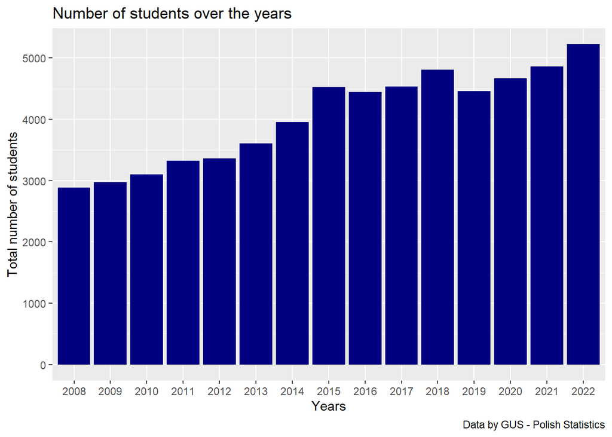

```r
p1 <- ggplot(df_short, mapping = aes(x=children_to_14, y=total_students))+geom_point()+geom_smooth()+labs(x="Population of children up to 14 years old", y="Total number of students", title="Number of children vs students", caption = "Data by GUS - Polish Statistics")

ggplot(df_short, mapping = aes(x=year, y=total_students))+geom_col(fill='navy')+labs(x="Years", y="Total number of students", title="Number of students over the years", caption = "Data by GUS - Polish Statistics")
```

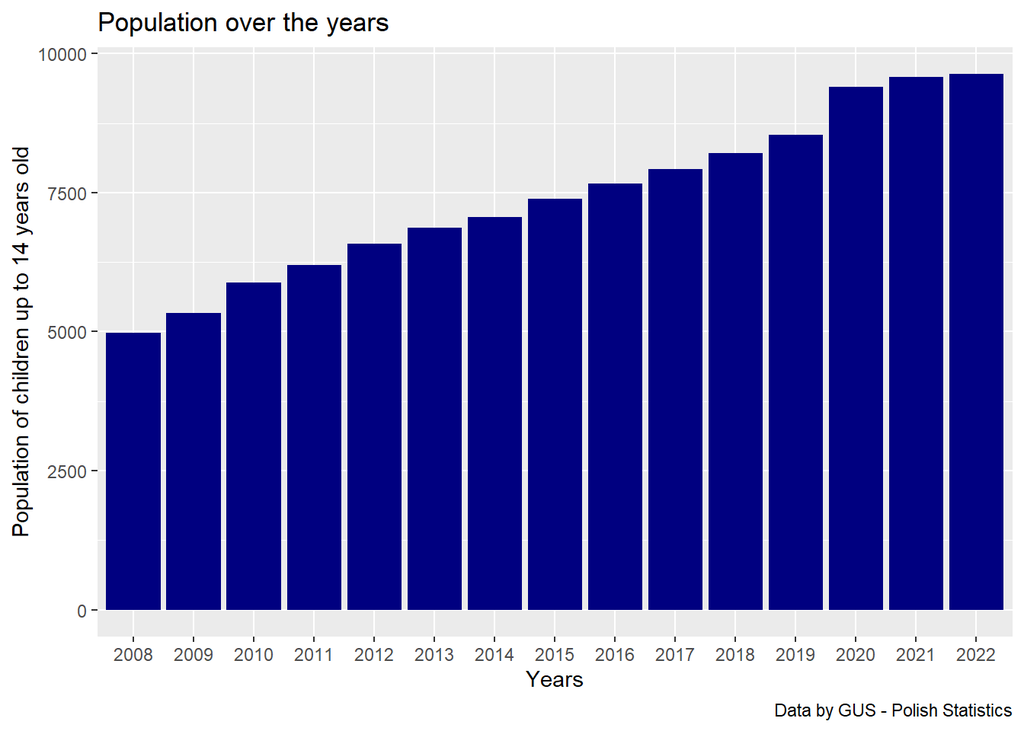

```r
ggplot(df_short, mapping = aes(x=year, y=children_to_14))+geom_col(fill='navy')+labs(x="Years", y="Population of children up to 14 years old", title="Population over the years", caption = "Data by GUS - Polish Statistics")
```

It is time to plot average values, to see how looks like number of students per class and number of classes per school.

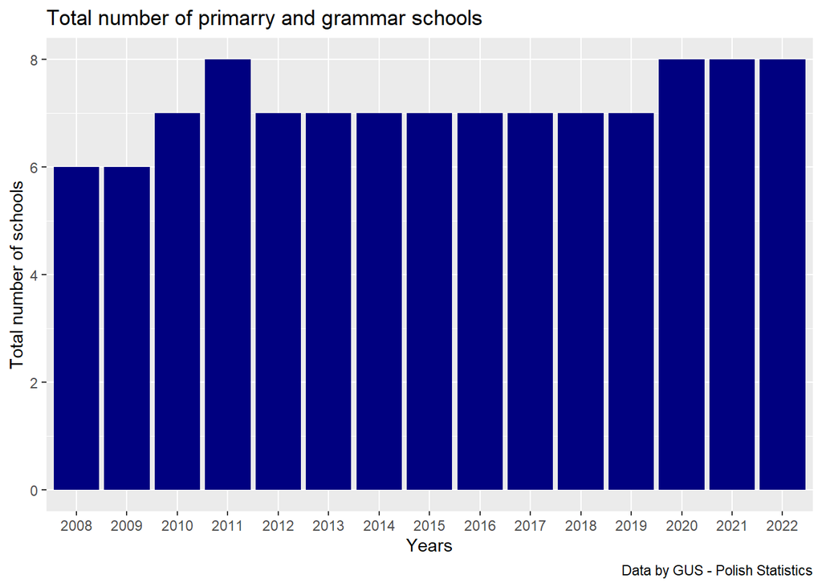

```r
ggplot(df_short, mapping = aes(x=year, y=total_schools))+geom_col(fill='navy')+labs(x="Years", y="Total number of schools", title="Total number of primarry and grammar schools", caption = "Data by GUS - Polish Statistics")
```

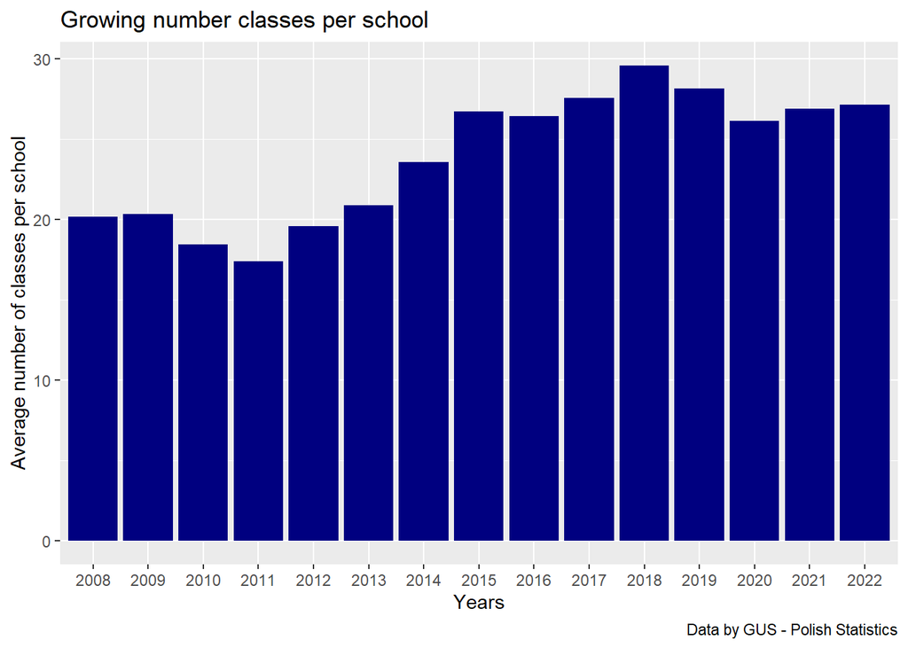

```r
ggplot(df_short, mapping = aes(x=year, y=average_classes_per_school))+geom_col(fill='navy')+labs(x="Years", y="Average number of classes per school", title="Growing number classes per school", caption = "Data by GUS - Polish Statistics")
```

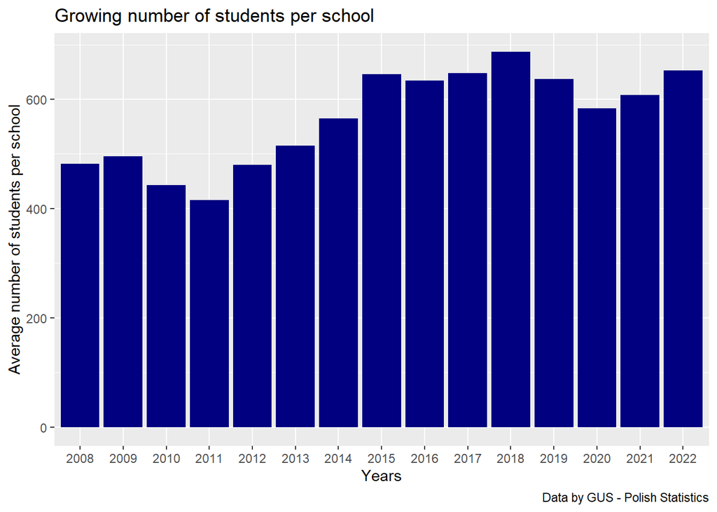

```r
ggplot(df_short, mapping = aes(x=year, y=average_students_per_school))+geom_col(fill='navy')+labs(x="Years", y="Average number of students per school", title="Growing number of students per school", caption = "Data by GUS - Polish Statistics")
```

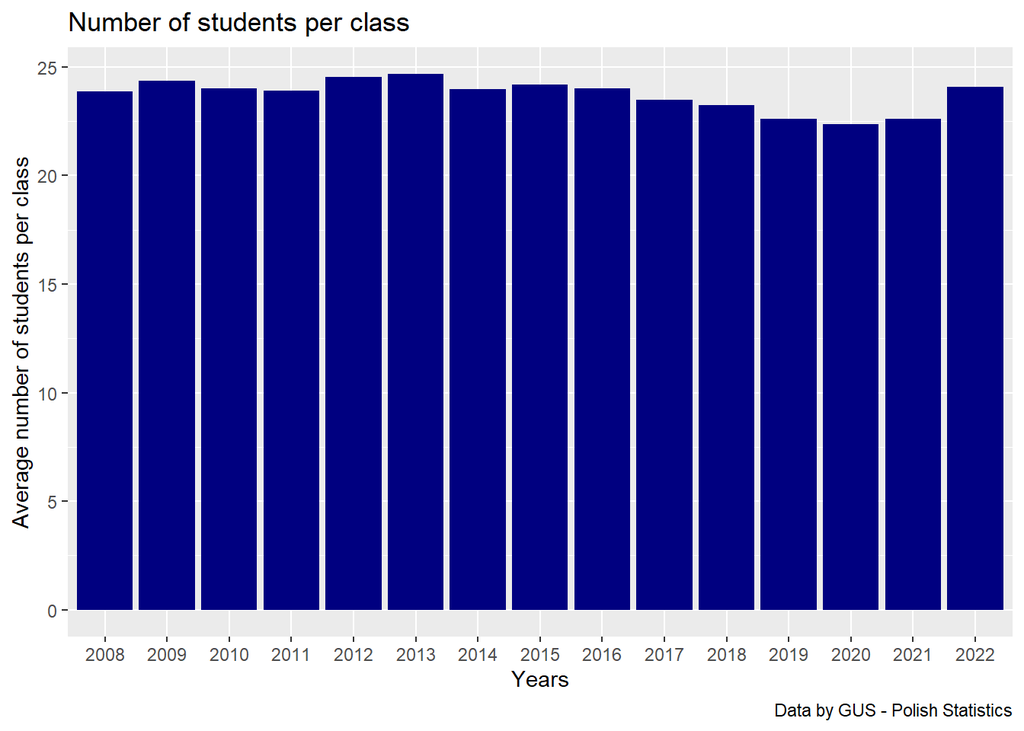

```r
ggplot(df_short, mapping = aes(x=year, y=average_students_per_class))+geom_col(fill='navy')+labs(x="Years", y="Average number of students per class", title="Number of students per class", caption = "Data by GUS - Polish Statistics")
```

## The answer

Due to constantly growing population of children in Ząbki, and in result growing number of students, town authorities should take necessary steps to build next primary school, and be ready to build next ones.

As we can notice after small drop in 2020, when new school was opened, number of classes per school is constantly growing, with slightly growing number of students per class. What is very important, average number of classes per school is significantly higher than in 2008, what most likely mean that all schools are already overloaded.

To be able to prepare more precise analysis it would be required to check chow number of classrooms have changed overtime. Unfortunately those data were incomplete in GUS database.